# A visual story of packaged drinks observed in a supermarket

## Introduction

This visual data story I use is to explores packaged drinks observed in a supermarket website using observational logging. Each response in the data set represents one observed drink item. The data includes drink type, carbonation status, no-sugar status, volume in ml, packaging type, and time stamp.

## Which drink types appeared most often?

The first visualisation shows how many observed drinks in each drink category. It helps to find out which types of drinks appeared more often in the supermarket.

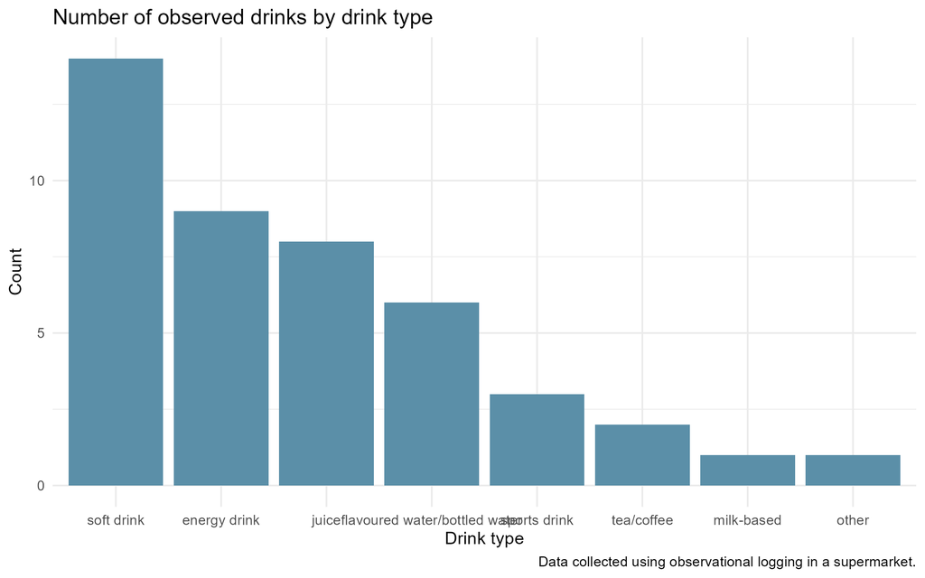

Bar chart showing the number of observed drinks by drink type.

This plot shows that some drink categories appeared more often than others, which may reflect what was more visible during the observation period.

## Which packaging types tended to have larger average volumes?

The next visualisation shows the average drink volume for each packaging type. This makes a comparison between packaging and the amount of drink usually associated with it.

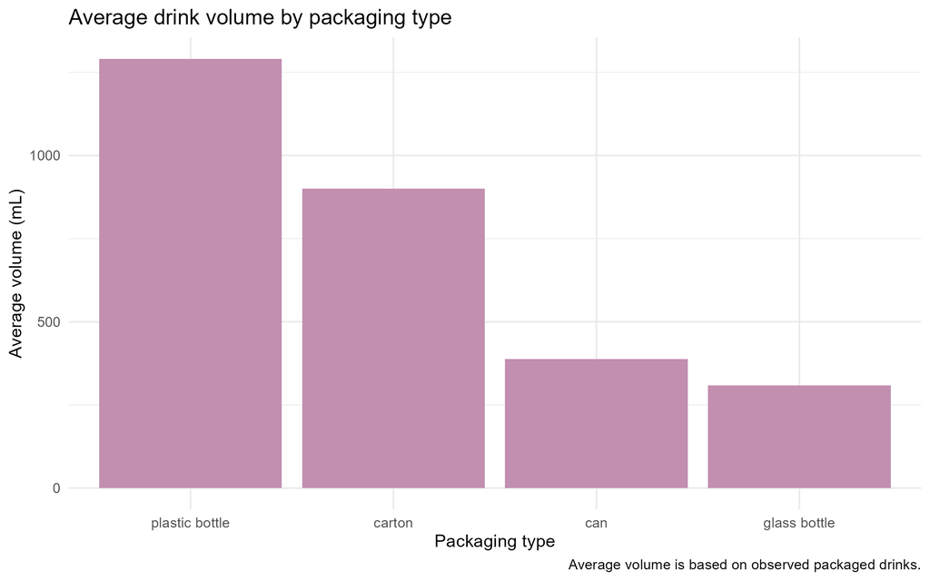

Bar chart showing average drink volume by packaging type.

This pattern shows that packaging type may be related to drink size. Plastic bottles appear to be associated with larger drink volumes on average.

## When was the data collected?

The third visualisation uses the time stamp variable to show how many observations were recorded on different day. This adds a time dimension to the data story.

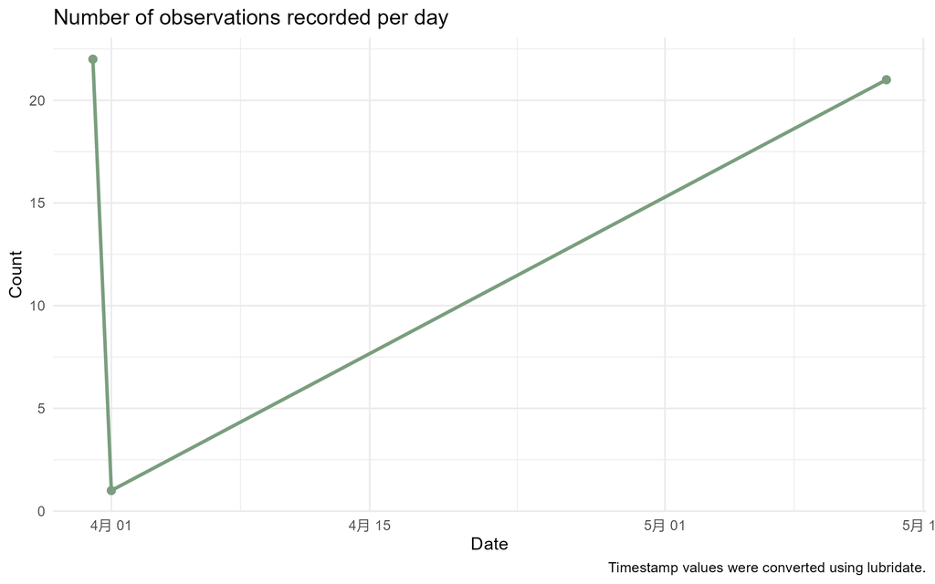

Line chart showing the number of drink observations recorded per day.

This chart shows that the observations were not distributed equally across different days. Instead, there were days with more active data collection than others.

## Conclusion

Using these three visualisations show that observational logging can reveal patterns in everyday supermarket products. The data story tells differences in drink type frequency, packaging and average volume, and the timing of data collection.